# Capitulo 2

```r
install.packages('plot3D')
```

Codigo de ejemplo.

## Simulations in R

Simulation 2.1. Below we simulate three trajectories of one-dimensional random walk. We assume the walk starts at zero, and specify p as 0.6 and the number of steps as 25.

```r
# specifying parameters
ntraj <- 3
p <- 0.6
nsteps <- 25

# Specifying seed
set.seed(45568223)

# defining walk as matrix
walk <- matrix(NA, nrow = nsteps, ncol = ntraj)

# Simulating trajectories
for (j in 1:ntraj){
  walk[1,j] <- 0
  for (i in 2:nsteps)
    walk[i,j] <- ifelse(runif(1)<p, walk[i-1, j]+1, walk[i-1,j]-1)
}

# plotting trajectories
matplot(walk, type="l", lty=1, lwd=2, col=2:4,
ylim=c(range(walk)), xlab="Step", ylab="Position",
panel.first=grid())
points(1:nsteps, walk[,1], pch=16, col=2)
```

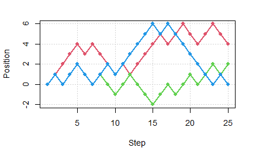

```r
points(1:nsteps, walk[,2], pch=16, col=3)
points(1:nsteps, walk[,3], pch=16, col=4)
```

### Simulation 2.2

The code blow simulates and plots a two-dimensional random walk with a total of 10,000 steps, emanating from the origin

```r
# specifying number of steps
nsteps <- 10000

# Specifying seed
set.seed(607335)

# Defining walk as matrix
walk <- matrix(NA, nrow = nsteps, ncol =2)

# setting starting point
walk[1,] <- c(0,0)

# Definiting random steps
rstep<- matrix(c(1, 0, -1, 0, 0, 1, 0, -1), nrow=4, ncol=2,
byrow=TRUE)

#simulating trajectories
for (i in 2:nsteps)
walk[i,]<- walk[i-1,] + rstep[sample(1:4, size=1),]
#plotting trajectories
plot(x=walk[,1], y=walk[,2], type="l", col="blue",
xlim=range(walk[,1]), ylim=range(walk[,2]), xlab="x",
ylab="y", panel.first=grid())
#adding starting point
points(cbind(walk[1,1], walk[1,2]), pch=16, col="green",
cex=2)
```

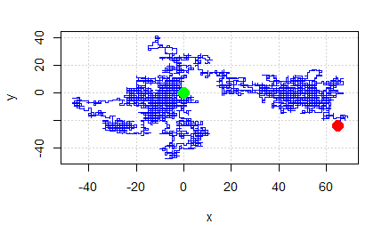

```r
#adding ending point
points(cbind(walk[nsteps,1],walk[nsteps,2]), pch=16,
col="red", cex=2)
```

### Simulation 2.3

The following code simulates and plots a three-dimensional random walk with 5,000 steps.

```r
#specifying number of steps
nsteps<- 5000
#specifying seed
set.seed(830126)
#defining walk as matrix
walk<- matrix(NA, nrow=nsteps, ncol=3)
#setting starting point
walk[1,]<- c(0,0,0)
#defining random steps
rstep<- matrix(c(1,0,0,-1,0,0,0,1,0,0,-1,0,0,0,1,0,0,-1),
nrow=6, ncol=3, byrow=TRUE)
#simulating trajectories
for (i in 2:nsteps)
walk[i,]<- walk[i-1,]+rstep[sample(1:6, size=1),]
#plotting trajectories
library(plot3D)
lines3D(walk[,1], walk[,2], walk[,3], col="blue",
xlim=range(walk[,1]), ylim=range(walk[,2]),
zlim=range(walk[,3]), xlab="x", ylab="y", zlab="z", bty="b2",
ticktype="detailed")
#adding starting point
points3D(x=walk[1,1], y=walk[1,2], z=walk[1,3], add=TRUE,
pch=16, col="green", cex=2)
```

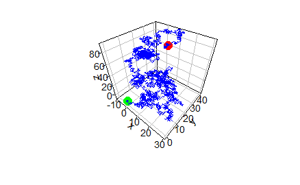

```r
#adding ending point
points3D(walk[nsteps,1], walk[nsteps,2], walk[nsteps,3],
add=TRUE, pch=16, col="red", cex=2)
```

### Aplication of Random Walk

Example:

```r
# Specifying parameters
p <- 0.55
i <- 10
N <- 20
ntraj <- 100000

# Defining walk as vector
walk <- c()

# Setting counters
nNs <- 0
nzeros <- 0
ngames <- 0

# Setting seed number
set.seed(30112443)

# Simulating trajectories until hitting N or 0
for (j in 1 : ntraj){
  walk[1] <- i
  k <- 2
  repeat{
    walk[k] <- ifelse(runif(1)<p, walk[k-1] + 1, walk[k-1]-1)
    ngames <- ngames + 1

    if (walk[k] == N){
      nNs <- nNs + 1
      break
    }

    else if(walk[k] == 0){
      nzeros <- nzeros +1
      break
    }
  k <- k + 1
  }
}

print(prob.Ns <- nNs/ntraj)
```

```
[1] 0.88279
```

```r
print(prob.zeros <- nzeros/ntraj)
```

```
[1] 0.11721
```

```r
print(mean.ngames<- ngames/ntraj)
```

```
[1] 76.18866
```

```r
p<- seq(0.35,0.65,0.001)
i<- 10
N<- 20
q<- 1-p
p.ruin<- ifelse(p==0.5,(N-i)/N,((q/p)^i-(q/p)^N)/(1-(q/p)
^N))


# plotting the graphs
plot(p,p.ruin, type = "l", lwd=2, col = "red", xlab="p",
ylab="Probability", panel.first = grid())
lines(p, 1-p.ruin, lwd=2, col = "green")
legend("right", c("Probability of $0", "Probability of $N"),
lty=1, col=2:3)
```

[output not shown]

```r
p <- seq(0.01, 1, 0.01)
i <- 10
N <- 20
q <- 1-p
E.ngames <- ifelse(p==0.5,i*(N-i),(i-N*(1-(q/p)^i)/(1-(q/p) ^N))/(1-2*p))

plot(p, E.ngames, type="l", lwd=2, col="green", xlab="p",
ylab="Expected number of games", panel.first=grid())
```

[output not shown]

```r
#specifying transition probability matrix
tm<- matrix(c(1,0,0,0,0,0,1/4,0,1/4,1/4,0,1/4,0,1/2,0,
1/2,0,0,0,1/4,1/4,0,1/4,1/4,1/3,0,0,1/3,0,1/3,0,1/3,0,1/3,1/
3,0), nrow=6, ncol=6, byrow=TRUE)
#setting counter
nsec<- 0
#estimating expected number of seconds
p<- matrix(NA, nrow=172, ncol=6)
p[1,]<- c(0, 0, 0, 1, 0, 0)
for (i in 2:172) {
p[i,]<- p[i-1,]%*%tm
nsec<- nsec+(i-1)*(p[i,1]-p[i-1,1])
}
print(nsec)
```

# Ejercicios:

### Excercise 2.1

In theory, $E(X_{50})=((2)(0.3)-1)(50) = -20~and~Var(X_{50})=(4)(0.3)(1/0.3)(50) = 42$

```r
# specifying parameters
p <- 0.3
n <- 50
ntraj<- 10000
#setting seed number
set.seed(546675)
#defining walk as matrix
walk<- matrix(NA, nrow=n, ncol=ntraj)
#simulating trajectories
for (j in 1:ntraj) {
 walk[1,j]<- 0
 for (k in 2:n) {
 walk[k,j]<- ifelse(runif(1)<p, walk[k-1,j]+1, walk[k-1,j]-1)
 }
}

mean(walk[50,])

var(walk[50,])
```

## Excersise 2.2

Consider a symmetric one-dimensional random walk that originates at 0. - Simulate 10,000 trajectories with 1,000 steps each. How many of the trajectories are at point 0 on the 1,000th step? - Find the theoretical probability of returning to 0 on the 1,000th step. Compare to the empirical value.

```r
# setting counter to zzero
nzeros <- 0

# Specifying seed
set.seed(675572)

# Defining walk as matrix
walk <- c()

# Simulating trajectories
for (j in 1: 10000){
  walk[1] <- 0
  for (i in 2 : 1001)
    walk[i] <- ifelse(runif(1)<0.5, walk[i-1]+1, walk[i-1]-1)
 if (walk[1001]==0) nzeros=nzeros+1
}
print(nzeros)
```

```
[1] 253
```

1. The theoretical probability of returning to - on the 1,000th step is:
   $$P(X_{1000} = 0\mid X_0
   =0)\begin{pmatrix}1000\\500\end{pmatrix}\left(\frac{1}{2}\right)^{1000}
   = 0.025$$
   This quantity was computed in R:

```r
choose(1000, 500)*0.5 ^1000
```

```
[1] 0.02522502
```

# Exercise 2.3

Simulate 10,000 trajectories of 1D, 2D, and 3D summetric random walks that start at the origin and continue for at most 1,000 steps. - Compute how many of them returned to the origin at least once. Compare the results for different dimensions. Hint: Terminate a trajectory when it returns to the origin. - Consider only the trajectories that returned to the origin within the 1,000 steps. Compute the average number of steps it took these trajectories to return to the origin. Compare the results for differentdimensions.

```r
#setting counters to zero
n1D<- 0
n2D<- 0
n3D<- 0
#specifying seed
set.seed(300799)
#defining 1D walk as vector
walk1D<- c()
nsteps1D<- c()
#simulating 1D trajectories
for (j in 1:10000)
 {
 walk1D[1]<- 0 #setting initial value to zero
 for (i in 2:1001)
 {
 walk1D[i]<- ifelse(runif(1)<0.5, walk1D[i-1]+1, walk1D[i-1]-1)
 if (walk1D[i]==0) {
 n1D=n1D+1
 break }
 }
 nsteps1D[j]=i
}


# Defining 2D walk as matrix
walk2D <- matrix(NA, nrow = 1001, ncol = 2)
nsteps2D <- c()

# Defining randoms steps
rstep2D<- matrix(c(1, 0, -1, 0, 0, 1, 0, -1), nrow=4, ncol=2, byrow=TRUE)

#simulating 2D trajectories
for (j in 1 : 10000)
{
  walk2D[1,] <- c(0,0) # setting initial value to origin
  for (i in 2:1001)
  {
    walk2D[i,] <- walk2D[i-1,]+rstep2D[sample(1:4, size=1),]
    if (walk2D[i,1]==0 & walk2D[i,2]==0) {
      n2D = n2D + 1
      break  }
  }
  nsteps2D[j] = i
}

#defining 3D walk as matrix
walk3D<- matrix(NA, nrow=1001, ncol=3)
nsteps3D<- c()

#defining random steps
rstep3D<- matrix(c(1, 0, 0,-1, 0, 0, 0, 1, 0, 0, -1, 0, 0, 0, 1, 0, 0, -1),
nrow=6, ncol=3, byrow=TRUE)
#simulating 3D trajectories
for (j in 1:10000)
{
 walk3D[1,]<- c(0,0,0) #setting initial value to the origin
 for (i in 2:1001)
 {
 walk3D[i,]<- walk3D[i-1,]+rstep3D[sample(1:6, size=1),]

 if (walk3D[i,1]==0 & walk3D[i,2]==0 & walk3D[i,3]==0) {
 n3D=n3D+1
 break }
 }
 nsteps3D[j]=i
}

print(n1D)
print(n2D)
print(n3D)
```

[output not shown]

- The average number of steps it took those trajectories to return to the origin is computed as:

```r
mean(nsteps1D[nsteps1D!=1001])
```

```
[1] 27.47499
```

```r
mean(nsteps2D[nsteps2D!=1001])
```

```
[1] 61.47625
```

```r
mean(nsteps3D[nsteps3D!=1001])
```

```
[1] 27.83689
```

The 97.6% of the 1D trajectories that returned to the origin, did it in 27.47 steps, on average. The 67.6% of the 2D trajectories that returned to the origin, did it in 61.48 steps, on average. The 33.3% of the 3D trajectories that returned to the origin, did it in 27.84 steps, on average

## Exercise 2.4

Simulate 10,000 trajectories of a two-dimensional symmetric random walk that starts at the origin and continues for a maximum of 1,000 steps. - Estimate the probability of a trajectory ever hitting the vertical barrier $x=30$ - Estimate the average number of steps it takes a trajectory to hit the barrier, provided it did hit the barrier within the 1,000 steps. - Estimate the expected value of the y-coordinate at the time when the random walk hits the barrier. What should this value be from the theoretical point of view? Hint: deduce from a symmetry argument.

The R script below simulates the trajectories and terminates them if the barrier is hit. Otherwise, trajectories continue for 1,000 steps. The total number of trajectories that hit the barrier is counted. We also record the number of steps (for part (b)) and the 𝑦𝑦-coordinate (for part (c)).

```r
# Setting counter to zero
nhits <- 0

# specifying seed
set.seed(50118)

# defining walk as matrix
walk <- matrix(NA, nrow = 1001, ncol = 2)
nsteps <- c()
ycoord <- c()

# Defining random steps
rstep <- matrix(c(1, 0, -1, 0, 0, 1, 0, -1), nrow=4, ncol=2, byrow=TRUE)

#simulating trajectories
for (j in 1:10000)
 {
 walk[1,]<- c(0,0) #setting initial value to the origin
 for (i in 2:1001)
 {
 walk[i,]<- walk[i-1,] + rstep[sample(1:4, size=1),]

 if (walk[i,1]==30) {
 nhits=nhits+1
 break }
 }
 nsteps[j]<- i
 ycoord[j]<- ifelse(i==1001, 99999, walk[i,2])
}
print(nhits)
```

```
[1] 1764
```

So, of the 10,000 trajectories, 1,764 hit the vertical barrier. Thus, the estimated probability to hit the barrier is 0.1764.

2. The average number of steps it takes a trajectory to hit the barrier, provided it did hit the barrier within the 1,000 steps, is estimated as:

```r
mean(nsteps[nsteps!=1001])
```

```
[1] 623.2053
```

It took on average 623.2 steps to hit the barrier for the 17.64% of the trajectories that terminated at the barrier.

1. Estimate the expected value of the 𝑦𝑦-coordinate at the time when the random walk hits the barrier. What should this value be from the theoretical point of view? Hint: deduce from a symmetry argument.

```r
mean(ycoord[ycoord!=99999])
```

```
[1] 0.1066364
```

The estimated average 𝑦𝑦-coordinate for 17.64% of the trajectories that hit the barrier was 0.1066. From the theoretical viewpoint, using the symmetry of the random walk, we can argue that the y-coordinate should be equal to 0.